# Panorama Geral dos dados coletados no site CifraClub

Andressa Santos

2026-03-24

# Panorama geral os dados

Das 5978 músicas do banco original, foram obtidas as cifras de 4829 no CifraClub; aproximadamente **80,78%** das canções.

Foram coletadas **9 variáveis** para cada uma:

- `...1`: índice automático
- `ID`: índice na tabela “dados_música” e proveniente do banco original
- `Nome`: nome da música
- `Artista`: nome do artista
- `Tom`: tom da música (em que escala a canção é tocada originalmente)
- `Capotraste`: variável binária que indica a presença ou não de capotraste (ferramenta que altera o formato dos acordes)
- `Letra_cifra`: letra e cifra da música (algumas também com tablaturas)
- `Compositor`: escritores da música
- `Ano`: ano em que emplacou no top 100

# Número de músicas com cifras disponíveis no CifraClub por ano

### 1 - Análise descritiva

```r
musicas_ano <- table(df$Ano)
summary(as.numeric(musicas_ano))
```

```
##    Min. 1st Qu.  Median    Mean 3rd Qu.    Max.
##   27.00   75.00   86.00   80.48   90.25   99.00
```

### 2 - Visualização

No boxplot e através dos dados sumarizados, é possível notar que 75% dos anos conta com ao menos 75 de suas 100 músicas registradas no site.

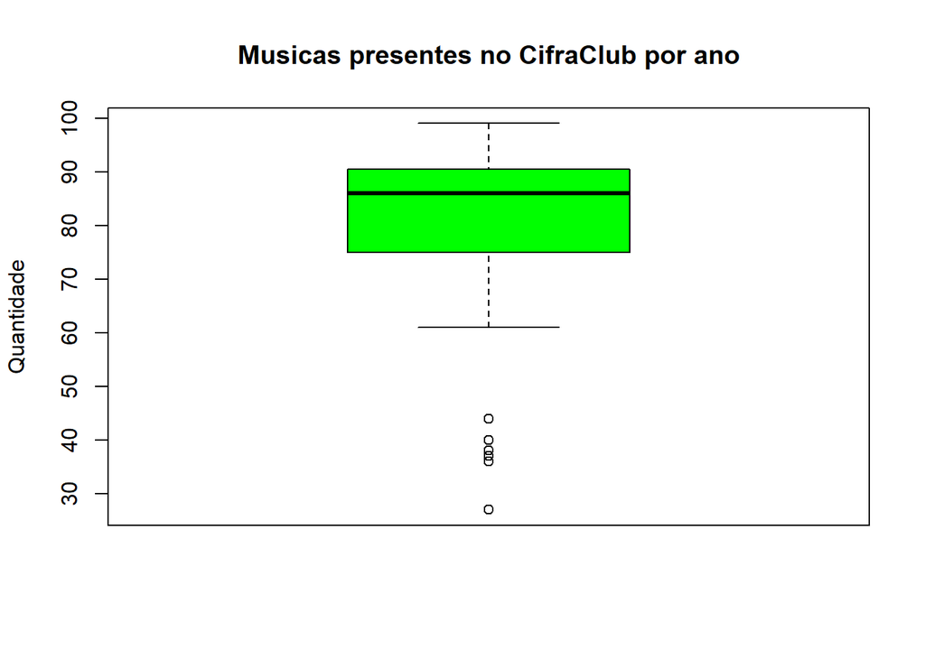

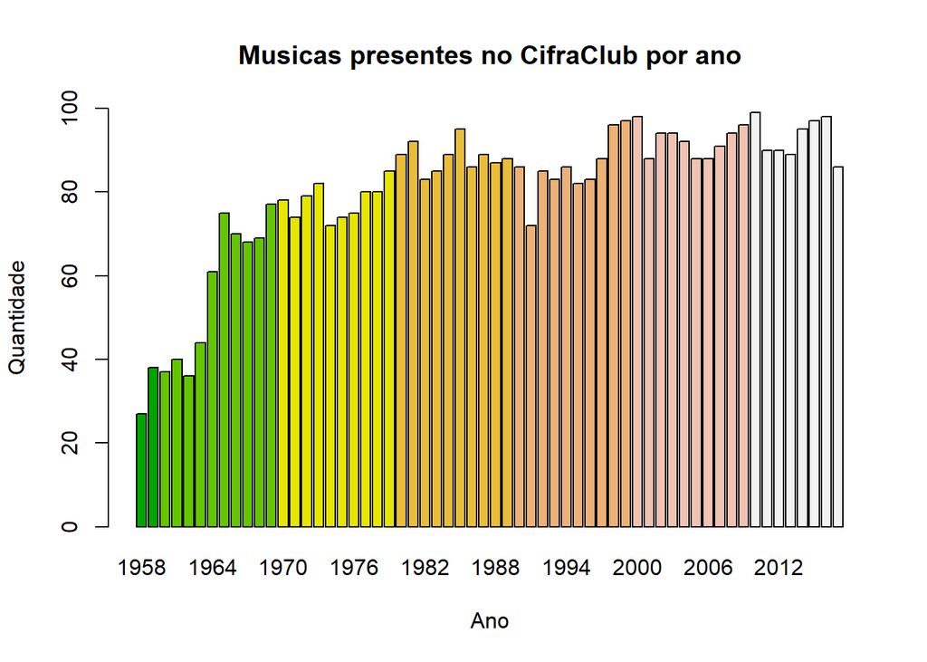

As faixas de cores representam décadas: do verde mais escuro que representa os anos 50 (com apenas 1958 e 1959) ao branco, referente aos anos entre 2010 e 2017.

Obs.: A utilização do gráfico de barras pode parecer não adequada, pois a variável do eixo x é numérica. Porém, nesse caso, estamos considerando os anos como rótulos e não como valor contínuo.

# Proporção de tons das músicas

### 1 - Análise descritiva

Nesse caso, vale a pena inserir a tabela completa. Vemos que músicas em escalas menores (exemplo: Em) são bem menos comuns na prática do que as provenientes de escalas maiores (exemplo: G).

```r
musicas_tom <- table(df$Tom)
musicas_tom
```

```
##
##   A  Ab  Am   B  Bb Bbm  Bm   C C#m  Cm   D  Db  Dm   E  Eb Ebm  Em   F  F# F#m
## 635 110 108 154 150  16  54 794  34  41 584 110  66 397 126  20 105 376 121  37
##  Fm   G G#m  Gm
##  29 688  14  56
```

```r
summary(as.numeric(musicas_tom))
```

```
##    Min. 1st Qu.  Median    Mean 3rd Qu.    Max.
##    14.0    40.0   109.0   201.0   209.5   794.0
```

### 2 - Visualização

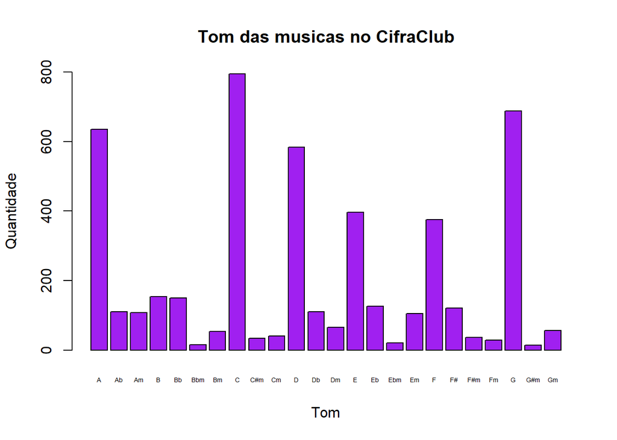

O gráfico ratifica as informações da tabela. Além disso, vemos que as escalas mais comuns tocadas em geral foram C, D, E, F, G e A (dó, ré, mi, fá, sol e lá).